# README

Materials for evaluating the ASCI index. See the sister repository [here](https://github.com/SCCWRP/ASCI) for the complete package.

Files in `data` folder created in `R/dat_proc.R` unless otherwise noted:

- `aldat.RData` data frame of additional algal index scores by site, date, sample
- `demo_algae_tax_gen.RData` demo algae data from ASCI package, genus level id
- `demo_algae_tax_spp.RData` demo algae data from ASCI package, species level id
- `orgdat.RData` Original ASCI results from Susie’s code
- `pkgdat.RData` Complete ASCI results from `sitein` and `taxain_spp`, using ASCI package
- `pmmilkup_gen.RData` pmmi lookup tables from ASCI package, genus level id
- `pmmilkup_spp.RData` pmmi lookup tables from ASCI package, species level id
- `psa.RData` sf object of California PSA regions
- `rawmet_gen.RData` All algal metric at genus level
- `rawmet_spp.RData` All algal metric at species level
- `sitcat.RData` Site categories as reference (cal/val), intermediate, stressed, and repeats (non-recent), includes PSA region
- `sitein.RData` Processed site data from raw data
- `taxain_spp.RData` Processed taxonomy data from raw data, species level
- `taxain_gen.RData` Duplicate file of taxain_spp where `FinalID` column is at genus level or higher

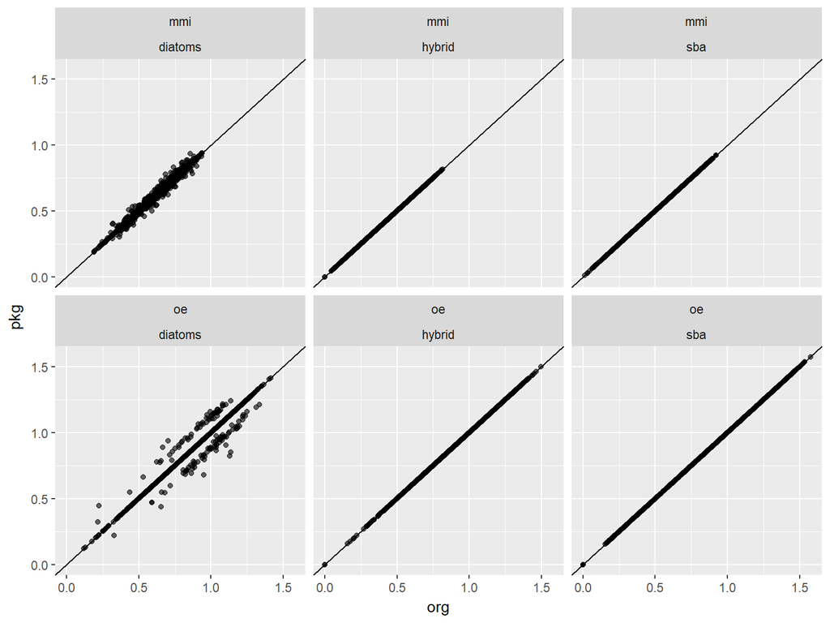

```r
pkgdat <- pkgdat %>%
  scores %>%
  dplyr::select(SampleID, taxa, OoverE, MMI) %>%
  rename(
    oe = OoverE,
    mmi = MMI,
    grp = taxa
    ) %>%
  gather('ind', 'scr', oe, mmi) %>%
  mutate(dat = 'pkg') %>%
  dplyr::select(SampleID, ind, grp, scr, dat)

toplo <- rbind(pkgdat, orgdat) %>%
  spread(dat, scr)

ggplot(toplo, aes(x = org, y = pkg)) +
  facet_wrap(ind ~ grp) +
  geom_point(alpha = 0.6) +
  geom_abline(intercept = 0, slope = 1)
```

Summary of performance:

```r
perf(allscr)
```

```
## # A tibble: 18 x 9
##    grp     ind   typ        cls     ave    fst prc_amg prc_wth res_tst
##    <chr>   <chr> <chr>      <chr> <dbl>  <dbl>   <dbl>   <dbl>   <dbl>
##  1 diatoms oe    Predictive rc    1.03   0.904  0.150   0.0963   11.6
##  2 diatoms oe    Predictive rv    0.961  0.786  0.225   0.0822    2.40
##  3 hybrid  oe    Predictive rc    1.04   1.60   0.160   0.0800   10.9
##  4 hybrid  oe    Predictive rv    1.03   2.29   0.186   0.109     5.49
##  5 sba     oe    Predictive rc    1.01   2.28   0.351   0.193    12.8
##  6 sba     oe    Predictive rv    0.737  1.66   0.367   0.178     3.60
##  7 diatoms mmi   Predictive rc    0.738 30.2    0.0942  0.0467   33.1
##  8 diatoms mmi   Predictive rv    0.749  9.23   0.0798  0.0412   24.4
##  9 hybrid  mmi   Predictive rc    0.573  2.57   0.0996  0.0539   29.2
## 10 hybrid  mmi   Predictive rv    0.587  1.33   0.0987  0.0399   19.7
## 11 sba     mmi   Predictive rc    0.673  1.63   0.129   0.0953   17.0
## 12 sba     mmi   Predictive rv    0.667  1.05   0.138   0.0743    9.72
## 13 diatoms oe    Null       rc    0.983 11.4    0.199   0.0853    4.29
## 14 diatoms oe    Null       rv    0.963  2.42   0.237   0.0915    1.36
## 15 hybrid  oe    Null       rc    1.06   1.28   0.184   0.0870    8.47
## 16 hybrid  oe    Null       rv    1.03   1.09   0.209   0.0852    3.05
## 17 sba     oe    Null       rc    0.889  5.71   0.388   0.174    10.0
## 18 sba     oe    Null       rv    0.768  1.71   0.400   0.183     4.10
```